# Корреспондентный анализ (Correspondence analysis)

## Матрица вкладов в формирование общей сопряженности (\(\chi^2\))

\[ \textbf{Q} = \frac {p_{ij} - p_ip_j}{\sqrt{p_ip_j}} = \frac{f_{ij}Ft - f_if_j}{Ft \sqrt{f_if_j}} \]

Матрица **Q** отличается от матрицы, содержащей \(\chi_{ij}\), только тем, что каждое ее значение разделено на \(\sqrt{Ft}\). То есть это будут стандартизованные значения (что очень полезно, так как собственные значения будут меньше или равны 1).

В этой матрице \(p_i\) и \(p_j\) маргинальные вероятности, то есть

\(p_{ij}\) - вероятность встретить особь данного вида в данной пробе

## Вычисляем матрицу вкладов в формирование общей сопряженности

Частоты и вероятности

```r
f_ij <- mite #Частота встречи данного вида в данной пробе, то есть это первичные даные!

p_ij <- mite/Ft #вероятность встречи данного вида в данной пробе

q <- p_i %*% t(p_j) #вероятность встретить особь в данной пробе.

Ft <- sum(mite) #Общее количество найденных животных

f_i <- apply(mite, MARGIN = 1, FUN = sum) #Общее количество особей в каждой пробе

p_i <- f_i/Ft #Вектор вероятностей встретить какую-либо особь в данной пробе

f_j <- apply(mite, MARGIN = 2, FUN = sum) #Общее количество особей в каждом виде

p_j <- f_j/Ft #Вектор вероятностей встретить особь данного вида
```

## Несколько слов о терминах

Матрица относительных частот `p_ij` для биолога имеет определенный смысл - это *оценки вероятностей встречи* особи данного вида в данной пробе.

НО! Терминология корреспондентного анализа берет свое начало в прикладной математике, во многом разработанной физиками. В терминологии корреспондентного анализа, суммы по строкам и столбцам в матрице относительных частот называются **массой строки** и **массой столбца**.

В прикладной математике у массы есть **инерция**.

*Момент инерции* - интеграл элемента массы умноженной на квадрат расстояния до центра масс.

- Простим - это математикам…

## Нулевая модель

Ожидаемые частоты для нулевой модели, то есть при условии, что все пробы и все виды независимы

```r
E <- (p_i %*% t(p_j) * Ft) # Ожидаемые частоты

O <- mite # Наблюдаемые частоты (первичные данные)
```

## Критерий \(\chi^2\)

```r
Chi2 <- sum((O-E)^2/E)
Chi2
```

```
## [1] 16621
```

В нашем случае сопряженность очень большая, то есть виды существуют в некоторой (неслучайной) зависимости от локальных условий (сайтов)

## Инерция

Вычислим величину, которую называют нормированным хи-квадратом, или *“инерцией”*

\[ Inertia = \frac{\chi^2}{Ft} \]

Она показывает удельный вклад каждой особи в формирование общего отклонения от нулевой модели

```r
Inertia <- Chi2/Ft
Inertia
```

```
## [1] 1.7
```

## Вычисляем матрицу вкладов в формирование общей сопряженности

\[ \textbf{Q} = \frac {p_{ij} - p_ip_j}{\sqrt{p_ip_j}} = \frac{f_{ij}Ft - f_if_j}{Ft \sqrt{f_if_j}} \]

```r
#Матрица, вычисленная через вероятности
Q1 <- (p_ij - p_i %*% t(p_j))/sqrt(p_i %*% t(p_j))

#Та же матрица, вычисленная через частоты
Q <- (f_ij*Ft - f_i %*% t(f_j))/(Ft*sqrt(f_i %*% t(f_j)))
```

## Сумма квадратов матрицы вкладов в формирование общей сопряженности

```r
Q <- as.matrix(Q)

sum(Q^2)
```

```
## [1] 1.7
```

Это та же самая \(Inertia\)!

## Inertia

Инерция - это мера отклонения от нулевой модели!

Чем больше инерция, тем сильнее взаимосвязаны изучаемые явления.

## SVD матрицы вкладов в формирование общей сопряженности

Матрица \(\textbf{Q}\) содержит информацию о вкладе каждого вида в каждой пробе в формирование отклонения от нулевой модели, то есть в формирование сопряженности проб и видов.

Вспомним теорему Экарта-Янга

\[ \textbf{Q}_{n \times p} = \textbf{U}_{n \times p} \textbf{D}_{p \times p} \textbf{V}'_{p \times p} \]

То есть, с помощью SVD мы сможем представить матрицу **Q** как результат произведения трех “вспомогательных” матриц.

Но! эти “вспомогательные” матрицы позволяют редуцировать исходную матрицу.

## SVD матрицы вкладов в формирование общей сопряженности

```r
U <- svd(Q)$u
D <- diag(svd(Q)$d)
V <- svd(Q)$v
```

## Размерности “вспомогательных” матриц

```r
dim(U)
```

```
## [1] 70 35
```

```r
dim(D)
```

```
## [1] 35 35
```

```r
dim(V)
```

```
## [1] 35 35
```

## Проверим восстаналивается ли матрица Q, если использовать “вспомогательные” матрицы, полученные в SVD

```r
Qsvd <- U %*% D %*% t(V) #матрица "восстановленная" из "вспомогательных" матриц

round(sum(Q - Qsvd)) #разность между исходной и "восстановленной" матрицами
```

```
## [1] 0
```

Матрица исходная и матрица восстановленная совпадают.  
Все работает!

## Поиск собственных значений и собственых векторов

Однако, разложив исходную матрицу на три “вспомогательных”, мы еще не достигли результата - нам необходимо произвести ординацию в **ортогональных** осях. Это можно сделать только с помощью собственных чисел и собственных векторов (eigen values decomposition).

Этот анализ можно произвести только на основе квадратной матрицы ковариации.

Как найти матрицу ковариации для матрицы вкладов в формирование общей сопряженности?

## Поиск собственных значений и собственых векторов

Вспомним: Собственные числа и собственные векторы мы искали для матрицы ассоциации (ковариации).

Эта матрица \(\textbf{A} = \textbf{X}' \textbf{X}\)

Где \(\textbf{X}\) - это **центрированная** матрица

Но! Центрованная матрица, по сути, и есть матрица отклонений от нулевой модели.

Нулевая модель в случае эвклдового простраства - Значения признака у всех объектов равны среднему.

## Поиск собственных значений и собственых векторов

В случае матрицы сопряжения \(\textbf{Q}\) - это тоже матрица отклонений от нулевой модели, поэтому

\[ \textbf {A} = \textbf{Q}'\textbf{Q} \]

Матрица **A** - квадратная симметричная матрица

## Поиск собственных значений и собственых векторов

```r
A <- t(Q) %*% Q

eig_values <- eigen(A)$values #Собственные числа матрицы A
eig_vectors <- eigen(A)$vectors #Матрица собственных векторов для матрицы A
```

## Сравним с результатами SVD

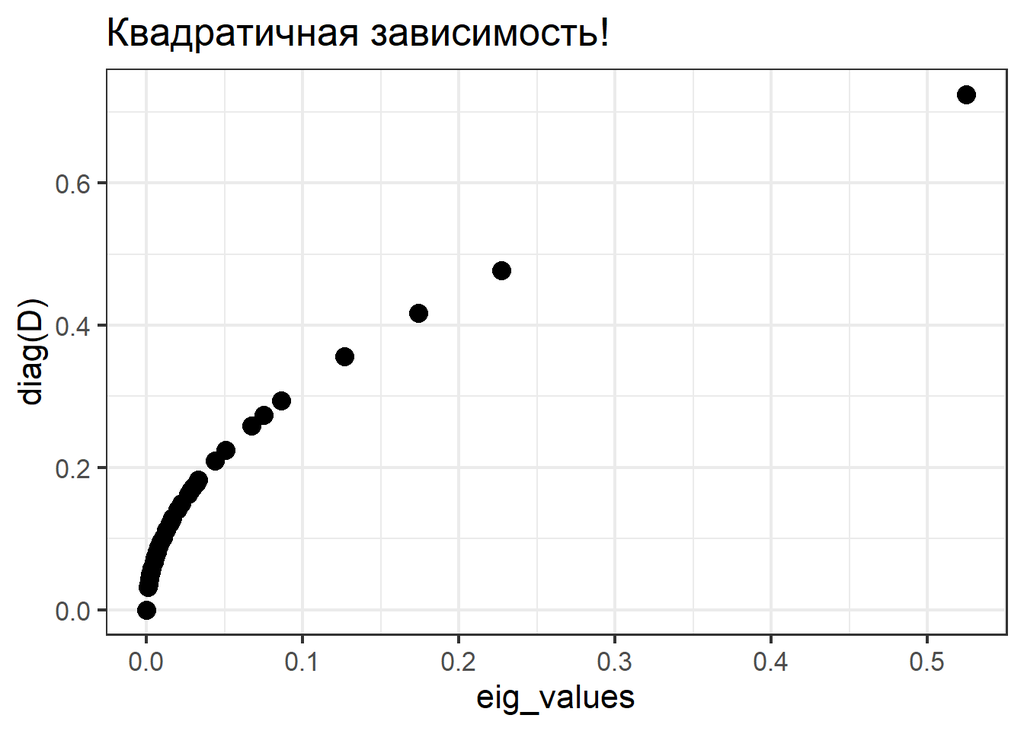

```r
qplot(eig_values, diag(D)) + ggtitle("Квадратичная зависимость!" )
```

## Сравним с результатами SVD

Квадраты сингулярных чисел матрицы **Q** равны собственным значениям матрицы ассоциации

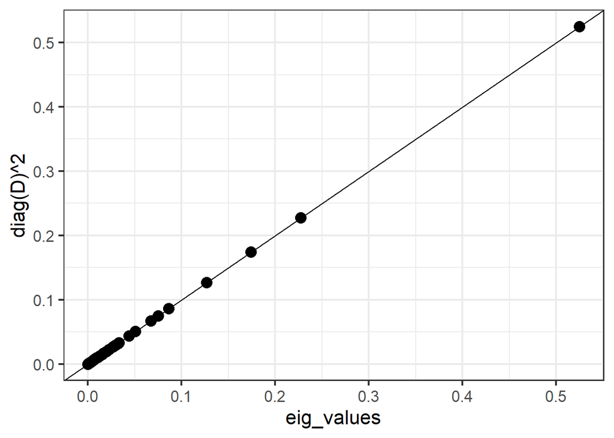

```r
qplot(eig_values, diag(D)^2 ) + geom_abline()
```

## Сравним с результатами SVD

**Обратите внимание на две особенности**

1. Собственные значения для матрицы ассоциации **A = Q’Q** равны квадратам сингулярных чисел для матрицы **Q**
2. Последнее собственное значение матрицы **A** равно нулю! Таково ее свойство (это связано с тем, что частоты в матрице **Q** центрированы). Поэтому в дальнейшем анализе будет использовано на одно собственное значение меньше.

## \(Inertia\) характеризует изменчивость в системе!

Вспомним, что мы вычислили показатель \(Inertia\), как сумму квадратов матрицы **Q**, или, что тоже самое, \(Inertia\) - это удельный \(\chi^2\). Из этого пока не следует, что \(Inertia\) показывает общую изменчивость в системе.

Вспомним, что общая дисперсия в системе - это сумма собственных значений. Ранее мы вычислили вектор `eig_values`, содержащий собственные значения матрицы ассоциации **A** = **Q’Q**. Найдем сумму всех собственных значений, то есть суммарную дисперсию.

```r
sum(eig_values)
```

```
## [1] 1.7
```

Это в точности значение \(Inertia\)!

## Главные оси

Вспомним суть перехода от одной системы координат к другой

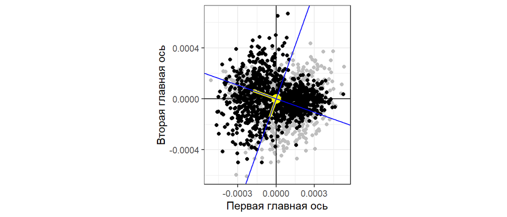

## Главные оси

В корреспондентном анализе оси, соответствующие собственным значениям матрицы **A**, называются *главными осями* (principal axes).

Информативность главных осей оценивается как отношение значения данного собственного числа к сумме собственных чисел, то есть к \(Inertia\)

```r
Information <- data.frame(
  CA = 1:length(eig_values),
  Eigenval =round(eig_values, 5),
  Prop_Explained = round(eig_values/sum(eig_values), 5),
  Cumul_Prop=round(cumsum(eig_values/sum(eig_values)),5)
  )

head(round(Information, 3))
```

```
##   CA Eigenval Prop_Explained Cumul_Prop
## 1  1    0.525          0.310      0.310
## 2  2    0.227          0.134      0.444
## 3  3    0.174          0.103      0.546
## 4  4    0.127          0.075      0.621
## 5  5    0.086          0.051      0.672
## 6  6    0.075          0.044      0.716
```

```r
tail(round(Information, 3))
```

```
##    CA Eigenval Prop_Explained Cumul_Prop
## 30 30    0.003          0.002      0.996
## 31 31    0.002          0.001      0.998
## 32 32    0.002          0.001      0.999
## 33 33    0.001          0.001      0.999
## 34 34    0.001          0.001      1.000
## 35 35    0.000          0.000      1.000
```

Обратите внимание, что последнее собственное значение (№35) равно нулю.

## Свойства главных осей

- Главные оси независимы друг от друга (перпендикулярны)
- Каждая последующая объясняет меньше общей инерции (общего \(\chi^2\))
- Всего осей может быть не больше чем минимальное из этих значений: (число строк - 1), (число столбцов - 1). Число осей зависит от меньшего из измерений. **Вспомним!** Строки и столбцы в матрице, которую мы изучаем равноправны.
- Первая ось - переменные, которые объясняют максимум зависимости строк от столбцов (значения которых сильнее всего отличаются от ожидаемых для данных объектов)
- Результаты изображаются в виде точечных графиков, похожих на биплоты.

## Scaling

В PCA мера расстояния между точками n-мерном пространстве – эвклидово расстояние

\[ D = \sqrt{\sum(y_{i,j} - y_{i,k})^2} \]

В CA мера расстояния между точками в n-мерном пространстве – расстояние \(\chi^2\)

\[ \chi^2 = \sqrt{ \sum {\frac{1}{f_{+j}/Ft}} \left( \frac{f_{1j}}{f_{1+}} - \frac{f_{2j}}{f_{2+}} \right)^2} \]

## Scaling

При ординации в CA должны сохраняться расстояния \(\chi^2\) расстояния

Но строки и столбцы равноправны! Следовательно при совместной ординации надо выбрать способ центрирования: либо по столбцам (scaling = 2, или scaling = “species” ), либо по строкам (scaling = 1, или scaling = “sites”)

**scaling 1** сохраняет \(\chi^2\) расстояния между объектами (строками)

**scaling 2** сохраняет \(\chi^2\) расстояния между признаками (столбцами)

## Нарисуем ординацию проб в первых двух главных осях

Для этого нам понадобятся первые две колонки матрицы U полученной в SVD (они соответствуют первым двум сингулярным числам и, стало быть, первым двум собственным значениям и первым двум собственным векторам).

Поскольку строки и столбцы матрицы **Q** равнозначны, то существет две точки отсчета, два центроида:

центроид строк (пробы) и центроид колонок(виды)

Координаты центроидов задаются векторами:

Центроид строк (пробы): `p_i`

Центроид колонок (виды): `p_j`

## Нарисуем ординацию проб в первых двух главных осях

Для вычисления координат проб (объектов, в нашем случае **строк** исходной матрицы) в *главных осях* необходимо значения, приведенные в матрице **U**, разделить на корень из значений координат центроида строк (\(\sqrt{p_i}\)), то есть произвести такую матричную операцию:

\[ \textbf {diag}(p_i)^{-1/2} \times U \]

```r
CA_samples <- diag(p_i^(-1/2))%*% U[,1:2]
```

```r
library(ggplot2)
Pl_CA_st <-
  ggplot(as.data.frame(CA_samples), aes(x=V1, y=V2) ) +
  geom_text(label = rownames(mite)) +
  geom_hline(yintercept=0, linetype = 2) +
  geom_vline(xintercept = 0, linetype = 2) +
  theme_bw() +
  labs(x= "CA1", y = "CA2")
```

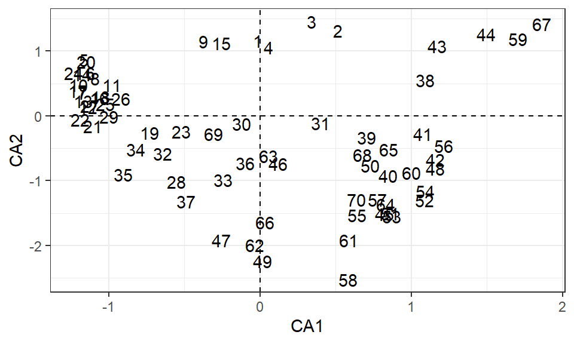

```r
Pl_CA_st
```

## Нарисуем ординацию видов в первых двух главных осях

Для вычисления координат видов (признаков, в нашем случае **столбцов** исходной матрицы) в *главных осях* необходимо значения, приведенные в матрице **V** разделить на \(\sqrt{p_j}\).  
То есть требуется провести следующее умножение матриц

\[ \textbf {diag}(p_j)^{-1/2} \times V \]

```r
CA_species <- diag(p_j^(-1/2))%*% V[,1:2]

Pl_CA_sp <-
  ggplot(as.data.frame( CA_species), aes(x = V1, y = V2) )  +
  geom_hline(yintercept=0, linetype = 2) +
  geom_vline(xintercept = 0, linetype = 2) +
  theme_bw() +
  labs(x= "CA1", y = "CA2") +
  geom_text(label = names(mite))
```

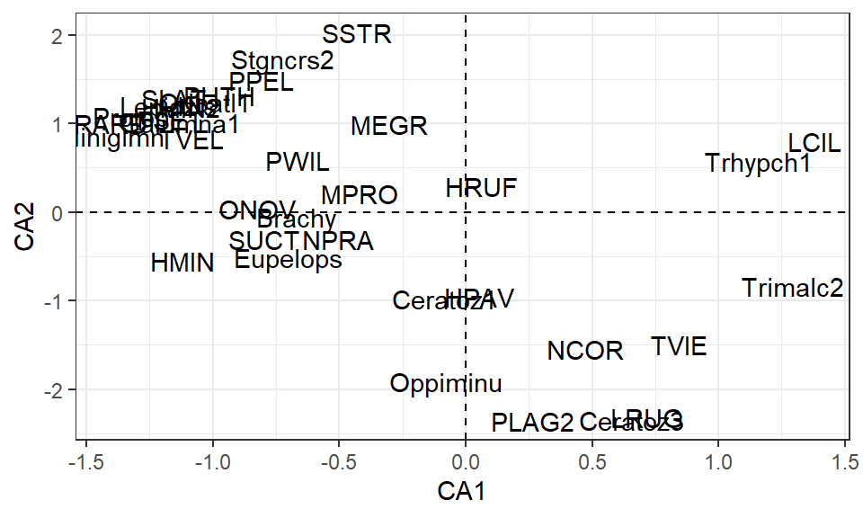

```r
Pl_CA_sp
```

## Сравним с результатами специализированной функции `cca()` из пакета `vegan`

Собственные значения,  
вычисленные функцией `cca()`

```r
summary(cca(mite))$cont$importance [, 1:4]
```

```
##                         CA1   CA2   CA3    CA4
## Eigenvalue            0.525 0.227 0.174 0.1266
## Proportion Explained  0.310 0.134 0.103 0.0747
## Cumulative Proportion 0.310 0.444 0.546 0.6209
```

Собственные значения,  
вычисленные вручную

```r
head(round(Information, 3), 4)
```

```
##   CA Eigenval Prop_Explained Cumul_Prop
## 1  1    0.525          0.310      0.310
## 2  2    0.227          0.134      0.444
## 3  3    0.174          0.103      0.546
## 4  4    0.127          0.075      0.621
```

Все аналогично!

## Сравним с результатами специализированной функции `cca()` из пакета `vegan`

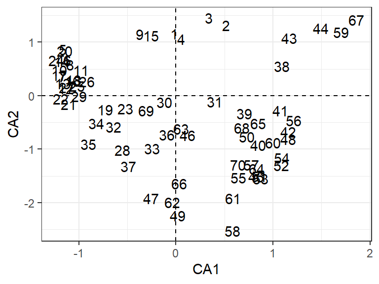

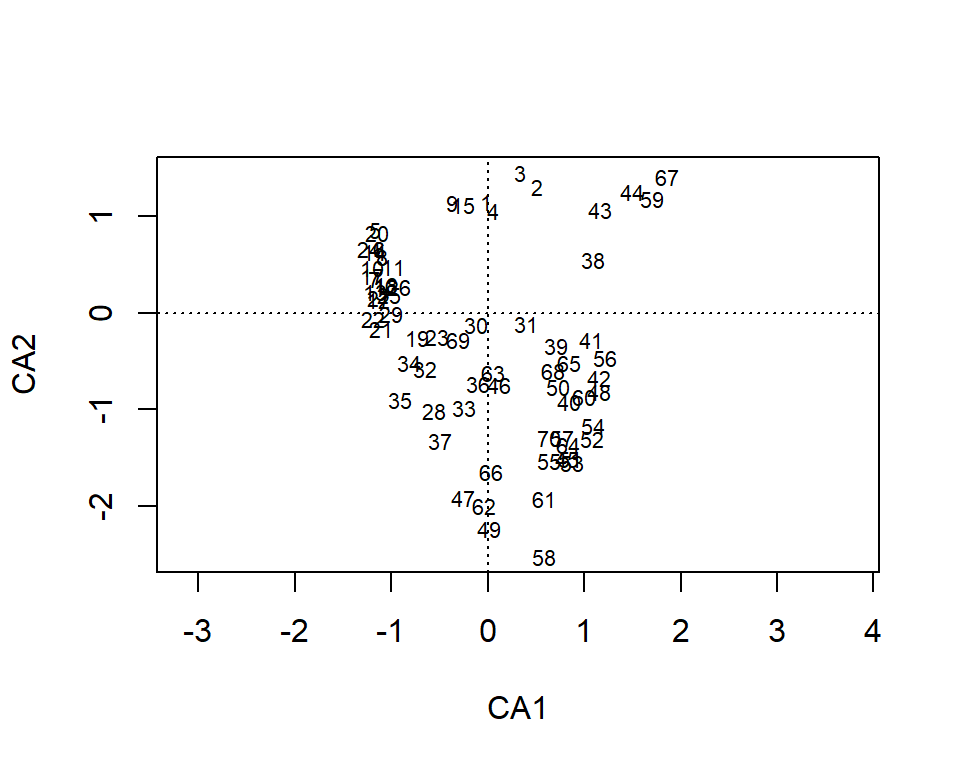

Ординация проб. Все аналогично результатам, полученным вручную!

## Сравним с результатами специализированной функции `cca()` из пакета `vegan`

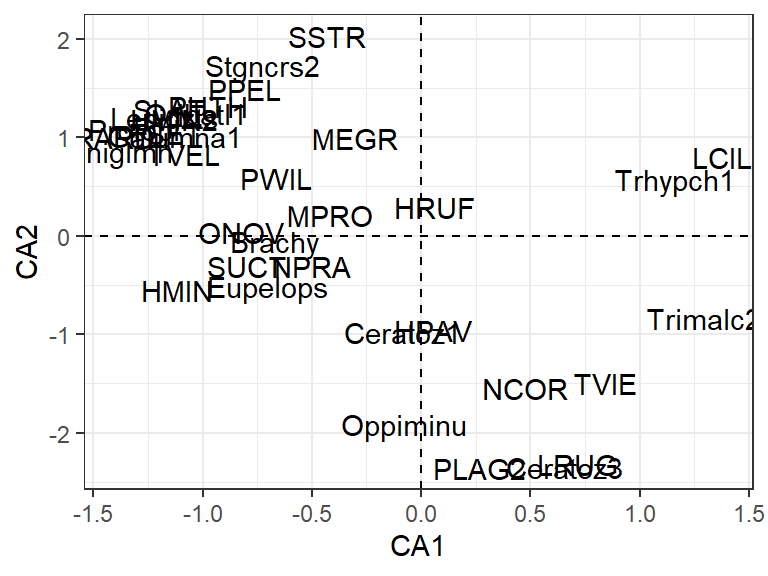

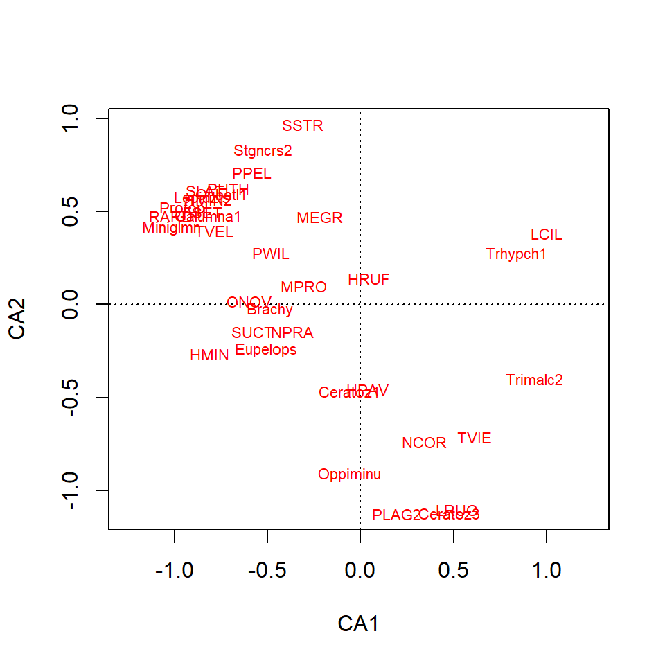

Ординация видов. Все аналогично результатам, полученным вручную!

## Визуализация результатов CA

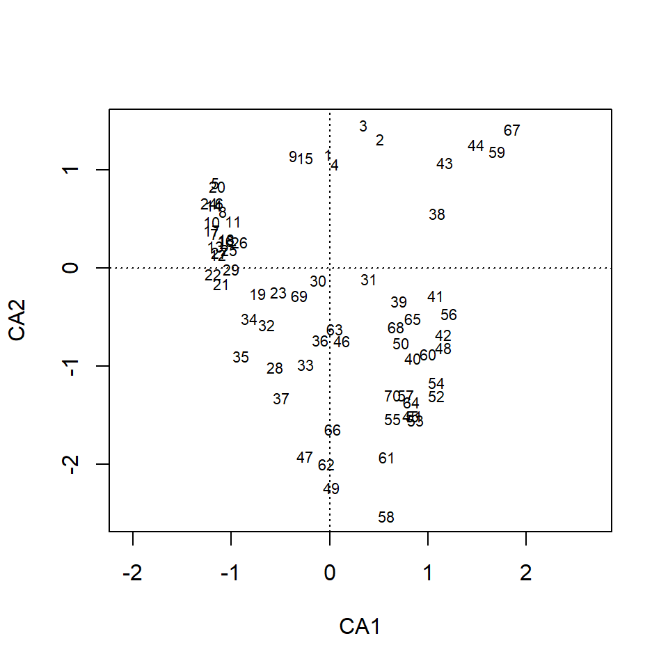

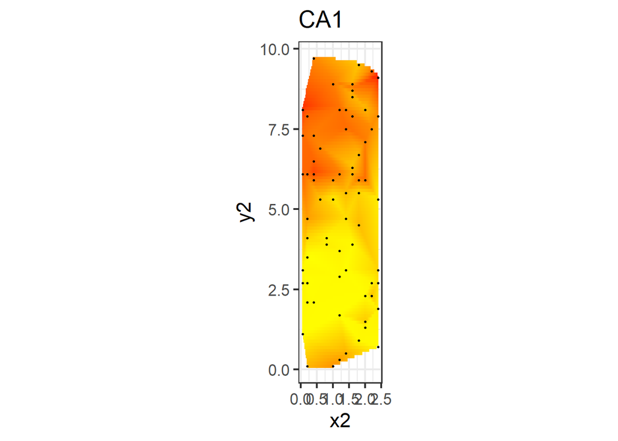

Становится виден отчетливый градиент!

## Задание

Проведите корреспондентный анализ для данных по птицам Австралии.

## Решение

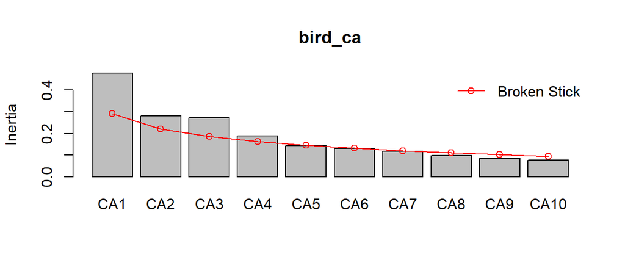

```r
bird_ca <- cca(birds[ , -c(1, 2)], scale = TRUE)
# summary(bird_pca)
screeplot(bird_ca,  bstick = TRUE) # график собственных чисел
```

## Решение

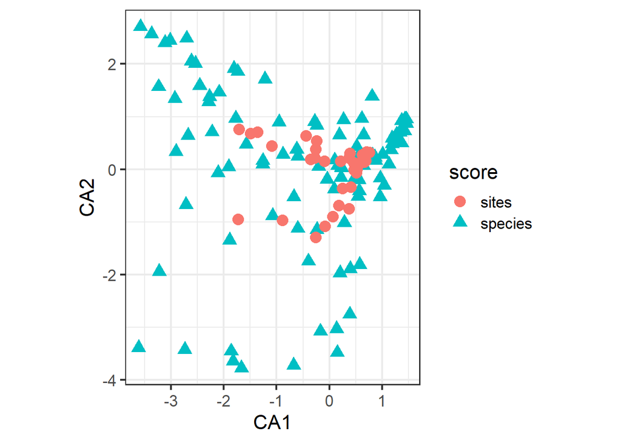

```r
# install.packages("remotes")
# remotes::install_github("gavinsimpson/ggvegan")

library(ggvegan)
autoplot(bird_ca, scaling = "sites")
```

## Sumary

Принципиальное отличие CA от PCA - это использование матрицы **Q** вместо матрицы исходных значений.  
Матрица **Q** - это матрица вкладов в формирование отклонения от нулевой гипотезы, говорящей, что сопряжения между явлениями нет.  
Вычислительный базис CA - это SVD матрицы **Q**

## Дополнительные ресурсы

- Borcard, D., Gillet, F., Legendre, P., 2011. Numerical ecology with R. Springer.
- Legendre, P., Legendre, L., 2012. Numerical ecology. Elsevier.
- Oksanen, J., 2011. Multivariate analysis of ecological communities in R: vegan tutorial. R package version 2–0.
- The Ordination Web Page URL http://ordination.okstate.edu/ (accessed 10.21.13).
- Quinn, G.G.P., Keough, M.J., 2002. Experimental design and data analysis for biologists. Cambridge University Press.
- Zuur, A.F., Ieno, E.N., Smith, G.M., 2007. Analysing ecological data. Springer.